# Glucocorticoid receptor dynamica

## Introduction

Glucocorticoids (GC) are a type of steroid hormones which are used by the immune system to repress inflammation. For this reason GCs are used as a medicine to treat inflammation in inflammatory diseases like asthma. The anti-inflammatory process caused by GCs can be divided into two processes: trans-repression and trans-activation. In trans-repression some inflammatory genes are suppressed by binding of the GCs to GC receptors (GR). This causes histon deacetylation of these genes and this causes for less transcription. In trans-activation the GRs activate transcription of anti-inflammatory genes by binding to DNA recognition sites on these genes. This activation is achieved by histon acetylation.

## Receptor-medicine interaction

When the MPL (D) is added it binds to the receptors (R) to form MPL-receptor complexes, leading to an increase in MPL-receptor density (DR). This DR is then being transferred to the nucleus (DR(N)), resulting in a higher DR(N) concentration. However, when the DR(N) concentration reaches a certain level it supresses the mRNA synthesis (the mRNA decreases to 50% of the base value). This then results in less R and therefor decreasing values of DR and DR(N).

## Model

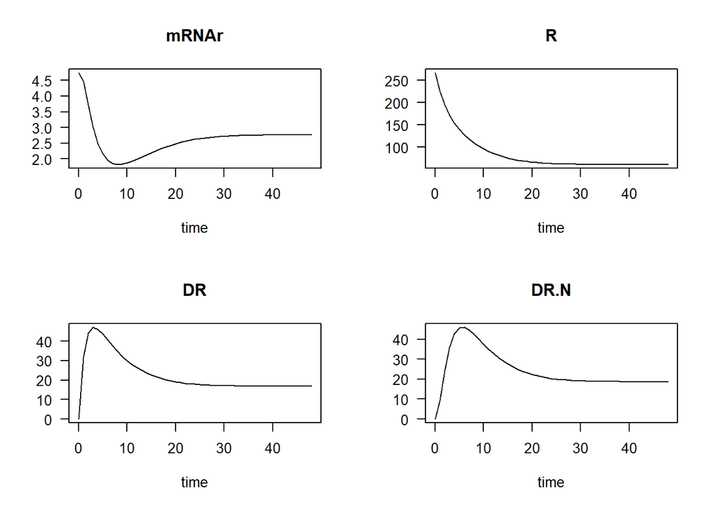

```r
library(deSolve)

mRNA.dynamic <- function(t, state, paramters) {
  with(as.list(c(state, paramters)),{
    dmRNAr <- ks.Rm * (1 - DR.N / (IC50.Rm + DR.N)) - k.dRm * mRNAr

    dR <- k.sR * mRNAr + Rf * k.re * DR.N - k.on * D * R - k.dR * R

    dDR <- k.on * D * R - k.T * DR

    dDR.N <- k.T * DR - k.re * DR.N

    list(c(dmRNAr, dR, dDR, dDR.N))
  })
}

parameters <- c(ks.Rm = 2.90,
                IC50.Rm = 26.2,
                k.on = 0.00329,
                k.T = 0.63,
                k.re = 0.57,
                Rf = 0.49,
                k.dR = 0.0572,
                k.dRm = 0.612,
                k.sR = 3.22,
                D = 20 * 1000 * 1/374.471 )

state <- c(mRNAr = 4.74,
           R = 267,
           DR = 0,
           DR.N = 0)

times <- seq(0, 48)

out <- ode(y = state, times = times, func = mRNA.dynamic, parms = parameters)
plot(out, las = 1)
```

## Result discussion

mRNAR is available in high concentration, because of this there is a high concentration of receptors and in a short period of time MPL-receptor complexes are made. This explains the steep increase of DR and DR.N. DR.N supresses the synthesis of mRNAR. Meanwhile the concentration of mRNAR decreases. At some point the mRNAR concentration is less than 50% of the initial value. DR.N doesn’t need to inhibit the synthesis of mRNAR anymore, so the concentration of DR.N decreases. Then mRNAR is synthesized until it is 50% of the initial value, after that an equilibrium is established in all 4 variables.